# Lech Academy Preseason

**Periodization:** The data is sampled from last season’s microcycles. The data is catagorized and summarized using the microcycle name.

## Re Entry

> The re entry session typically follows a day off or when comming off a holiday. The objective is to re-introduce the players to the physical loading in a controlled manner or process. The re-entry provides players more time to coordinate movements and improve reaction times. The training emphsises movement quality over quantity.

### Total Distance

Total Distance on a re-entry session is meant to range from $1500$ to $2500$. It is critical to work on technical football principles. Football activities that challenge the players foot speed, technical proficiency, and cognitive focus are better than activities that emphasis running volume and running intensity.

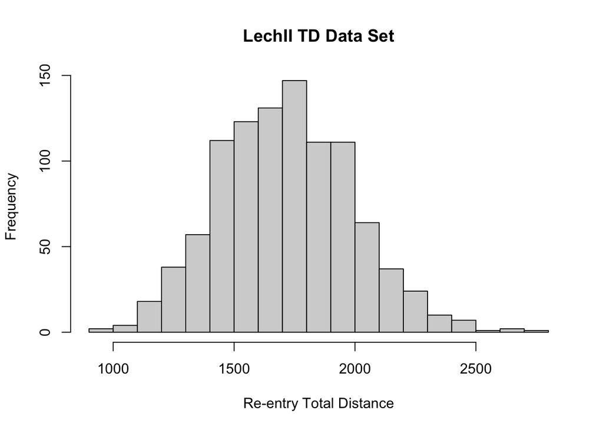

| td.mean | td.sd | td.se | td.min | td.max | td.n |
| --- | --- | --- | --- | --- | --- |
| 1715.399 | 276.5448 | 8.745116 | 906.977 | 2721.919 | 1000 |

|  | TD |
| --- | --- |
| 5% | 1279.986 |
| 15% | 1423.872 |
| 25% | 1526.848 |
| 35% | 1596.969 |
| 45% | 1672.269 |
| 55% | 1744.434 |
| 65% | 1814.754 |
| 75% | 1905.396 |
| 85% | 1988.676 |
| 95% | 2180.889 |

### HSR

HSR on a re-entry session is meant to range from $max(<100)$.

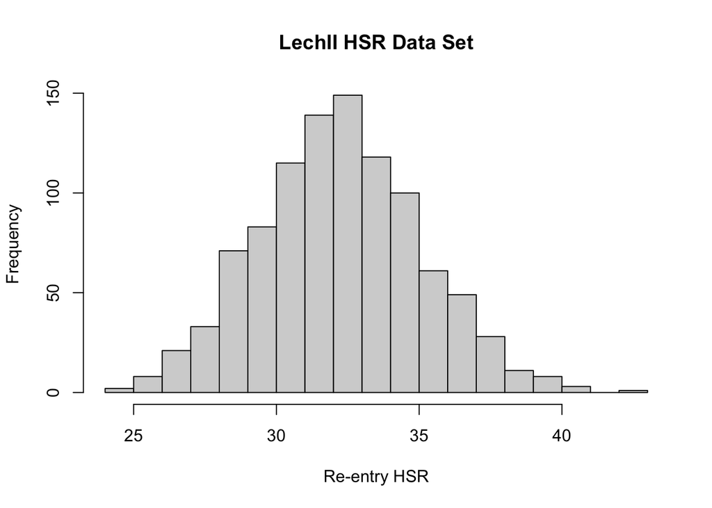

| hsr.mean | hsr.sd | hsr.se | hsr.min | hsr.max | hsr.n |
| --- | --- | --- | --- | --- | --- |
| 32.22368 | 2.838698 | 0.0897675 | 24.1907 | 42.1522 | 1000 |

|  | HSR |
| --- | --- |
| 5% | 27.72137 |
| 15% | 29.16803 |
| 25% | 30.33205 |
| 35% | 31.10797 |
| 45% | 31.80175 |
| 55% | 32.53106 |
| 65% | 33.24992 |
| 75% | 34.06708 |
| 85% | 35.13200 |
| 95% | 37.02739 |

### Accel Efforts

High Intensity Acceleration efforts on a re-entry session are meant to be lower. The goal is to keep Accel Efforts under $60$.

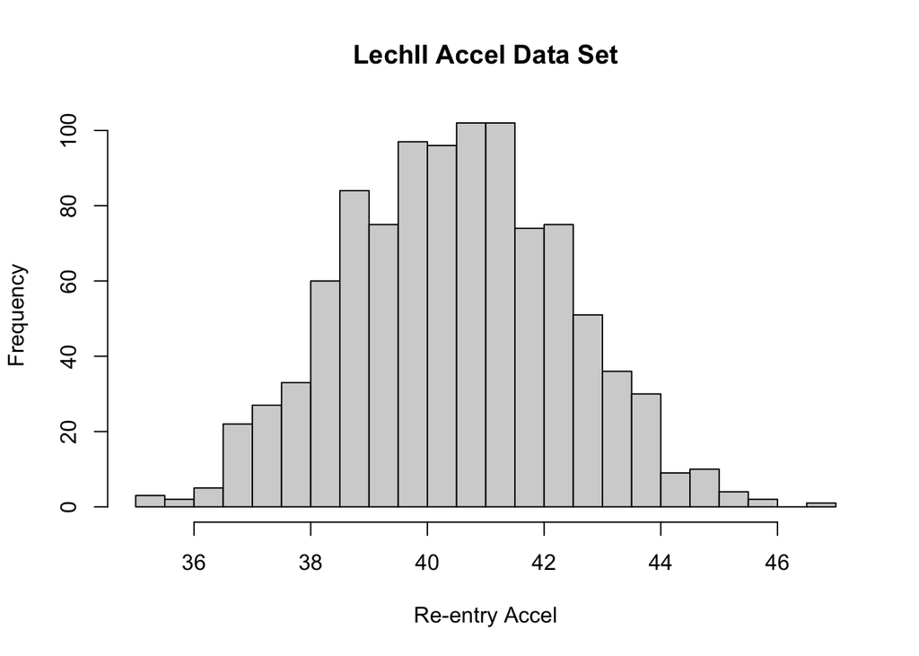

| accel.mean | accel.sd | accel.se | accel.min | accel.max | accel.n |
| --- | --- | --- | --- | --- | --- |
| 40.47755 | 1.882591 | 0.0595328 | 35.29 | 46.96 | 1000 |

|  | Accel Efforts |
| --- | --- |
| 5% | 37.3585 |
| 15% | 38.4785 |
| 25% | 39.1275 |
| 35% | 39.6930 |
| 45% | 40.2700 |
| 55% | 40.7700 |
| 65% | 41.2100 |
| 75% | 41.7825 |
| 85% | 42.4515 |
| 95% | 43.5905 |

### Decel Efforts

High Intensity deceleration efforts on a re-entry session are meant to be lower. The goal is to keep Accel Efforts under $60$.

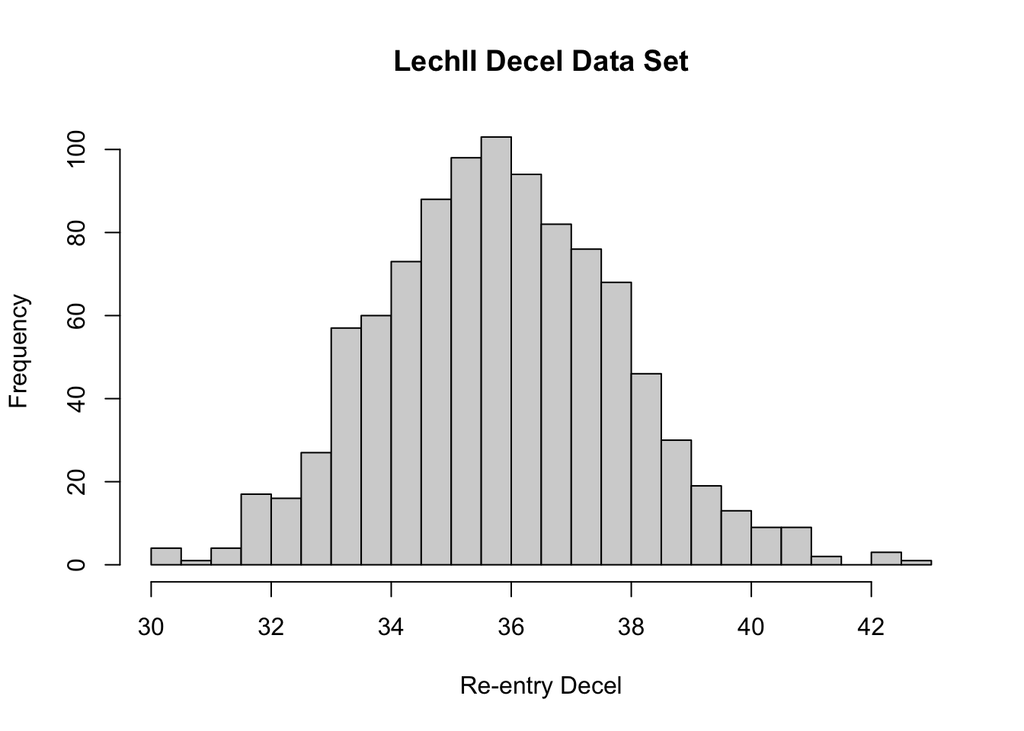

| decel.mean | decel.sd | decel.se | decel.min | decel.max | decel.n |
| --- | --- | --- | --- | --- | --- |
| 35.81969 | 1.997102 | 0.0631539 | 30.21 | 42.66 | 1000 |

|  | Decel Efforts |
| --- | --- |
| 5% | 32.6785 |
| 15% | 33.7900 |
| 25% | 34.4775 |
| 35% | 35.0200 |
| 45% | 35.5400 |
| 55% | 36.0145 |
| 65% | 36.5500 |
| 75% | 37.1600 |
| 85% | 37.8730 |
| 95% | 39.0915 |

## Intensive

> *High Intensity actions emphasises acceleration and deceleration patterns in training. Be very careful not to make the spaces to small. Small spaces will have the unintended consequence of reducing acceleration and deceleration efforts.*

### Total Distance

Total Distance on a intensive session is meant to range from $2500$ to $5000$. High intensity acceleration actions are meant to range from $80$ to $120$. Think of the intensive day as a strength building day. Minimize the athletes total running volume and emphasis intensity of the acceleration and deceleration actions. Develop the intended **Behaviors** on the pitch such as speed of regains, defensive actions, aggressive actions to minimize oppositions spaces.

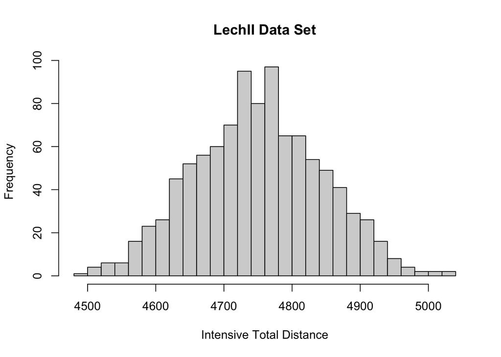

| td.mean | td.sd | td.se | td.min | td.max | td.n |
| --- | --- | --- | --- | --- | --- |
| 4750.469 | 93.4435 | 2.954943 | 4497.404 | 5035.343 | 1000 |

|  | TD |
| --- | --- |
| 5% | 4596.660 |
| 15% | 4650.948 |
| 25% | 4684.238 |
| 35% | 4715.792 |
| 45% | 4737.497 |
| 55% | 4761.370 |
| 65% | 4783.641 |
| 75% | 4815.216 |
| 85% | 4849.731 |
| 95% | 4907.768 |

### HSR

HSR on an intensive session is meant to range from $max(<150)$.

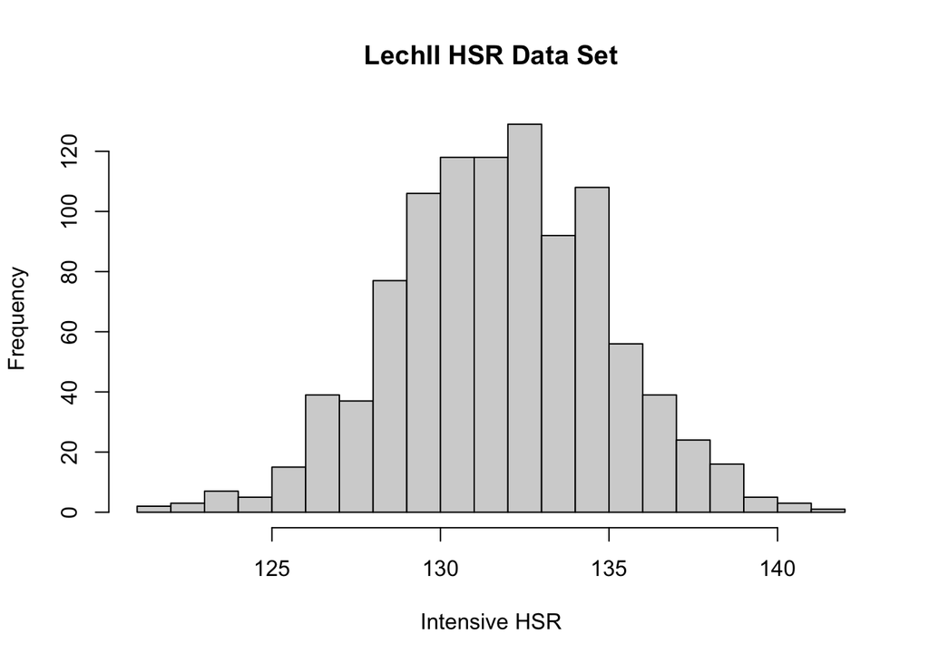

| hsr.mean | hsr.sd | hsr.se | hsr.min | hsr.max | hsr.n |
| --- | --- | --- | --- | --- | --- |
| 131.7444 | 3.167016 | 0.1001498 | 121.6662 | 141.83 | 1000 |

|  | HSR |
| --- | --- |
| 5% | 126.4736 |
| 15% | 128.5928 |
| 25% | 129.5745 |
| 35% | 130.4897 |
| 45% | 131.3199 |
| 55% | 132.1489 |
| 65% | 132.9269 |
| 75% | 134.0298 |
| 85% | 134.9353 |
| 95% | 136.9159 |

### Accel Efforts

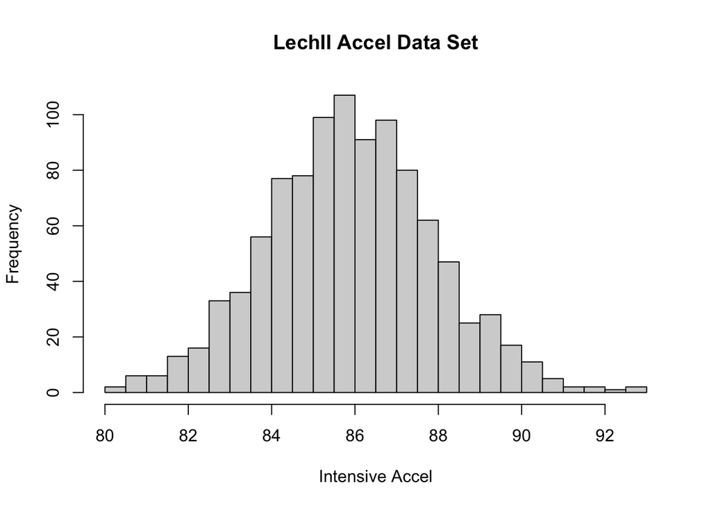

| accel.mean | accel.sd | accel.se | accel.min | accel.max | accel.n |
| --- | --- | --- | --- | --- | --- |
| 85.89545 | 2.002478 | 0.0633239 | 80.19 | 92.75 | 1000 |

|  | Accel Efforts |
| --- | --- |
| 5% | 82.6295 |
| 15% | 83.8785 |
| 25% | 84.5675 |
| 35% | 85.1065 |
| 45% | 85.6200 |
| 55% | 86.1445 |
| 65% | 86.6600 |
| 75% | 87.1800 |
| 85% | 87.9200 |
| 95% | 89.2615 |

### Decel Efforts

High Intensity deceleration efforts on an intensive session are meant to be high. The goal is to keep deceleration efforts above $90$. Ofcours, individual averages and variance must be considered in the analysis.

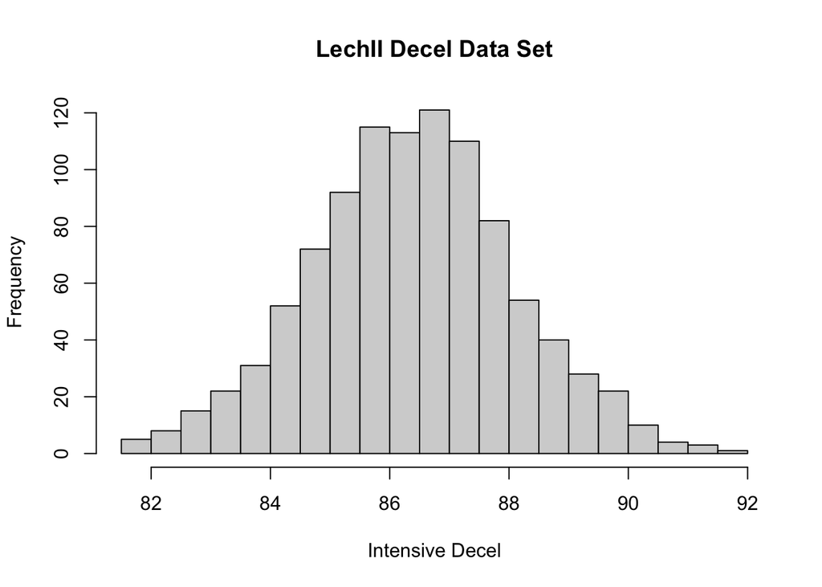

| decel.mean | decel.sd | decel.se | decel.min | decel.max | decel.n |
| --- | --- | --- | --- | --- | --- |
| 86.39012 | 1.716416 | 0.0542778 | 81.58 | 91.85 | 1000 |

|  | Decel Efforts |
| --- | --- |
| 5% | 83.5275 |
| 15% | 84.6355 |
| 25% | 85.2600 |
| 35% | 85.7400 |
| 45% | 86.2000 |
| 55% | 86.6045 |
| 65% | 87.0200 |
| 75% | 87.4700 |
| 85% | 88.0800 |
| 95% | 89.3205 |

## Extensive

### TD

> Extensive sessions build metabolic capacity and, critical to maintaining high intensity football actions, extensive sessions expose footballers to high speed running and repeated sprinting. Extensive session offer an opportunity to work in medium and large spaces. At the same time, work on team and player relationships/behaviors in different areas of the field.

Total Distance on an extensive session is meant to range from $5000$ to $8000$ meters. High volume running and high speed running is emphasized. ***

[figure not shown]

| td.mean | td.sd | td.se | td.min | td.max | td.n |
| --- | --- | --- | --- | --- | --- |
| 6066.751 | 166.7309 | 5.272493 | 5532.726 | 6578.692 | 1000 |

|  | TD |
| --- | --- |
| 5% | 5777.973 |
| 15% | 5899.705 |
| 25% | 5956.104 |
| 35% | 6002.887 |
| 45% | 6045.948 |
| 55% | 6091.640 |
| 65% | 6133.801 |
| 75% | 6188.990 |
| 85% | 6238.144 |
| 95% | 6333.018 |

### HSR

HSR on an intensive session is meant to push above an average of $>400$ meters.

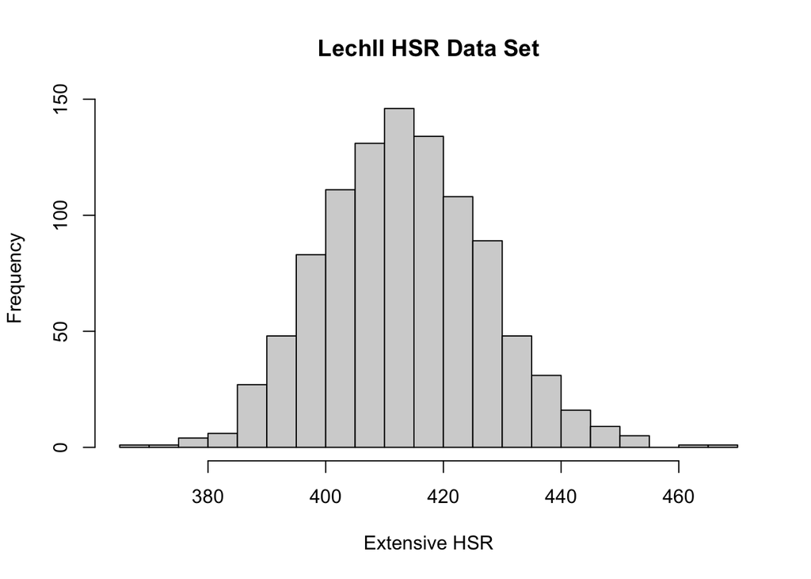

| hsr.mean | hsr.sd | hsr.se | hsr.min | hsr.max | hsr.n |
| --- | --- | --- | --- | --- | --- |
| 413.3782 | 13.84882 | 0.4379382 | 367.9874 | 465.199 | 1000 |

|  | HSR |
| --- | --- |
| 5% | 391.8429 |
| 15% | 398.9710 |
| 25% | 403.7840 |
| 35% | 407.9182 |
| 45% | 411.1355 |
| 55% | 414.7067 |
| 65% | 418.1965 |
| 75% | 422.0837 |
| 85% | 427.9548 |
| 95% | 436.7779 |

### Accel Efforts

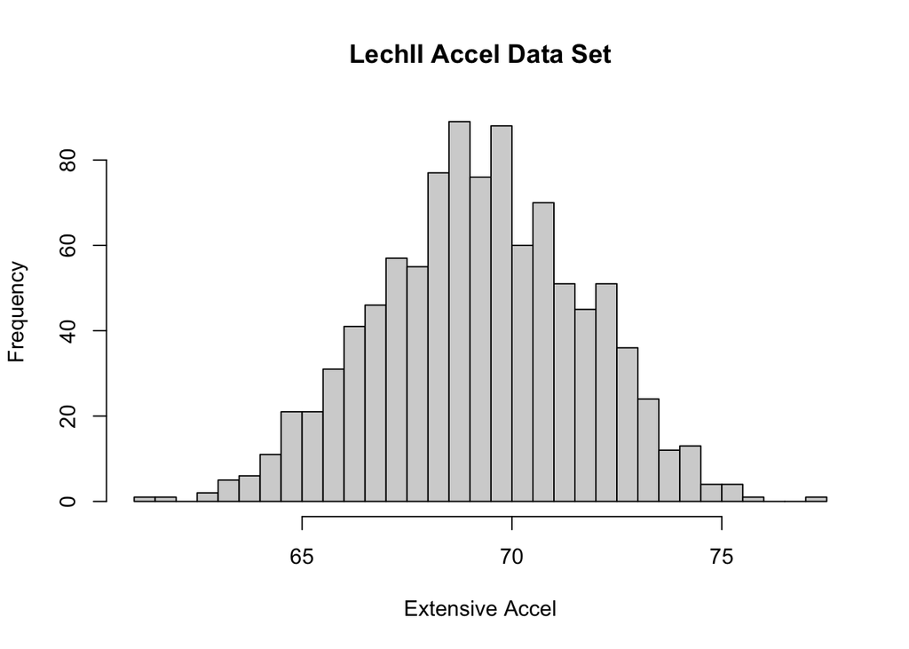

| accel.mean | accel.sd | accel.se | accel.min | accel.max | accel.n |
| --- | --- | --- | --- | --- | --- |
| 69.23801 | 2.456121 | 0.0776694 | 61.48 | 77.16 | 1000 |

|  | LII_quantile_accel.ext |
| --- | --- |
| 5% | 65.0495 |
| 15% | 66.6585 |
| 25% | 67.5575 |
| 35% | 68.3600 |
| 45% | 68.9100 |
| 55% | 69.5500 |
| 65% | 70.1600 |
| 75% | 70.9150 |
| 85% | 71.9815 |
| 95% | 73.1430 |

### Decel Efforts

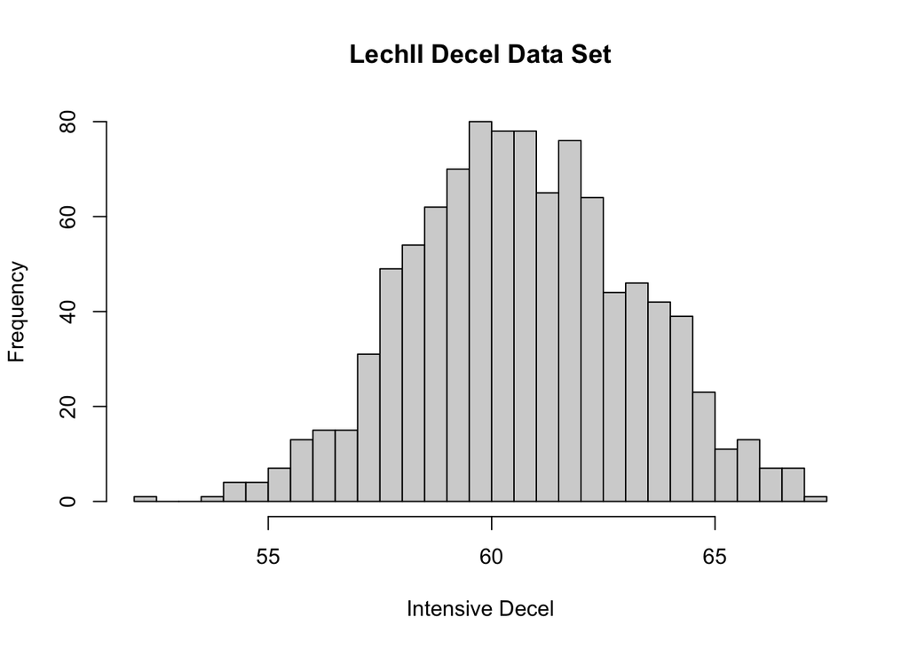

| decel.mean | decel.sd | decel.se | decel.min | decel.max | decel.n |
| --- | --- | --- | --- | --- | --- |
| 60.67871 | 2.480156 | 0.0784294 | 52.02 | 67.03 | 1000 |

|  | Decel Efforts |
| --- | --- |
| 5% | 56.6885 |
| 15% | 58.1000 |
| 25% | 58.9375 |
| 35% | 59.6665 |
| 45% | 60.2900 |
| 55% | 60.8900 |
| 65% | 61.6600 |
| 75% | 62.4000 |
| 85% | 63.4000 |
| 95% | 64.8405 |

## Taper

### TD

> Taper sessions are desiged to build reserves and allow players to begin the restoration and adaptation process. It is expected that we will reduce total training loads by at least 40%. Tapers typically start two days befor competition.

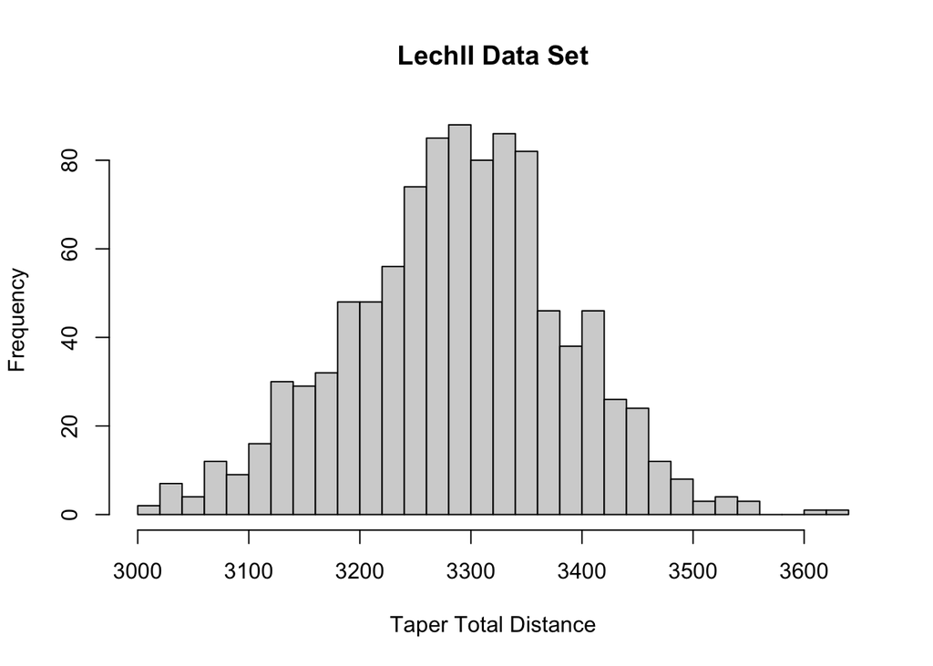

| td.mean | td.sd | td.se | td.min | td.max | td.n |
| --- | --- | --- | --- | --- | --- |
| 3287.266 | 98.16997 | 3.104407 | 3004.655 | 3636.602 | 1000 |

|  | TD |
| --- | --- |
| 5% | 3120.818 |
| 15% | 3184.566 |
| 25% | 3226.340 |
| 35% | 3254.491 |
| 45% | 3279.732 |
| 55% | 3301.738 |
| 65% | 3326.679 |
| 75% | 3350.325 |
| 85% | 3385.810 |
| 95% | 3444.296 |

### HSR

HSR during a taper should begin to dramatically drop:A 40% reduction of the extensive day would look something like: 171. This number was derived by 40% of the HSR number achieved on average plus the standard deviation from the extensive session.

[figure not shown]

| hsr.mean | hsr.sd | hsr.se | hsr.min | hsr.max | hsr.n |
| --- | --- | --- | --- | --- | --- |
| 412.6975 | 13.5994 | 0.4300508 | 370.7545 | 459.1442 | 1000 |

|  | HSR |
| --- | --- |
| 5% | 391.0916 |
| 15% | 398.0426 |
| 25% | 403.6128 |
| 35% | 407.2944 |
| 45% | 410.7119 |
| 55% | 414.6651 |
| 65% | 417.7875 |
| 75% | 421.4293 |
| 85% | 426.1071 |
| 95% | 435.4487 |

### Accel Efforts

[figure not shown]

| accel.mean | accel.sd | accel.se | accel.min | accel.max | accel.n |
| --- | --- | --- | --- | --- | --- |
| 69.31674 | 2.540563 | 0.0803397 | 60.55 | 76.14 | 1000 |

|  | LII_quantile_accel.ext |
| --- | --- |
| 5% | 65.0185 |
| 15% | 66.7985 |
| 25% | 67.5975 |
| 35% | 68.3465 |
| 45% | 69.0055 |
| 55% | 69.5845 |
| 65% | 70.2735 |
| 75% | 71.0850 |
| 85% | 72.0030 |
| 95% | 73.5405 |

### Decel Efforts

[figure not shown]

| decel.mean | decel.sd | decel.se | decel.min | decel.max | decel.n |
| --- | --- | --- | --- | --- | --- |
| 60.52117 | 2.412555 | 0.0762917 | 51.72 | 68.19 | 1000 |

|  | Decel Efforts |
| --- | --- |
| 5% | 56.6165 |
| 15% | 58.0385 |
| 25% | 58.8075 |
| 35% | 59.4965 |
| 45% | 60.2455 |
| 55% | 60.8900 |
| 65% | 61.4800 |
| 75% | 62.1525 |
| 85% | 63.1500 |
| 95% | 64.3710 |

### A1

**Periodization:** The data is sampled from last season’s microcycles. The data is catagorized and summarized using the microcycle name.

### Re-Entry

Total Distance on a re-entry session is meant to range from $1500$ to $2500$.

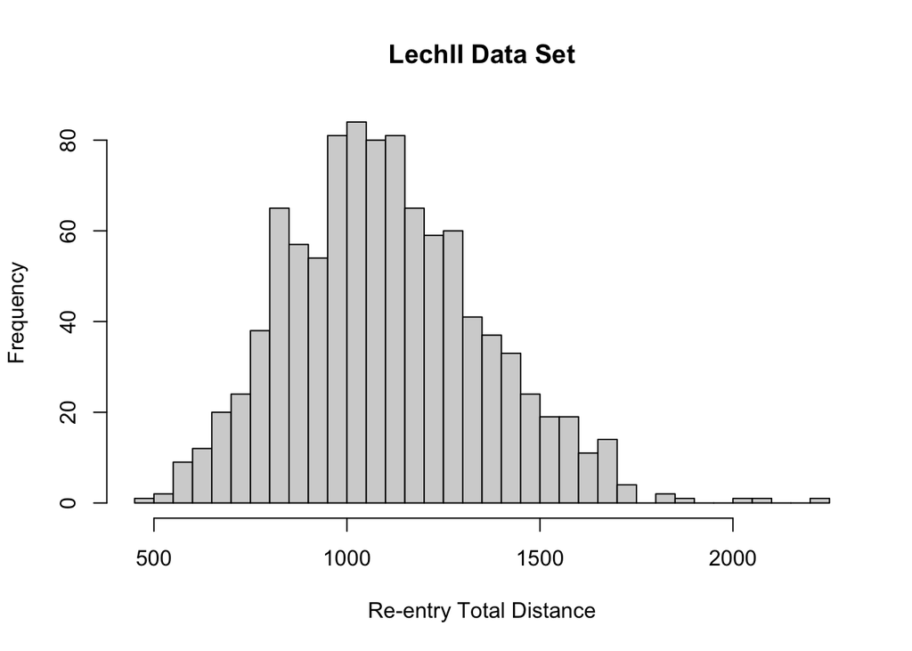

| td.mean | td.sd | td.se | td.min | td.max | td.n |
| --- | --- | --- | --- | --- | --- |
| 1101.767 | 253.8343 | 8.026946 | 497.7083 | 2211.709 | 1000 |

|  | TD |
| --- | --- |
| 5% | 723.7677 |
| 15% | 838.9703 |
| 25% | 923.0880 |
| 35% | 991.7573 |
| 45% | 1051.5572 |
| 55% | 1114.6417 |
| 65% | 1179.5394 |
| 75% | 1261.0943 |
| 85% | 1374.5706 |
| 95% | 1555.4570 |